# Day Care Fines

**Figure 3**

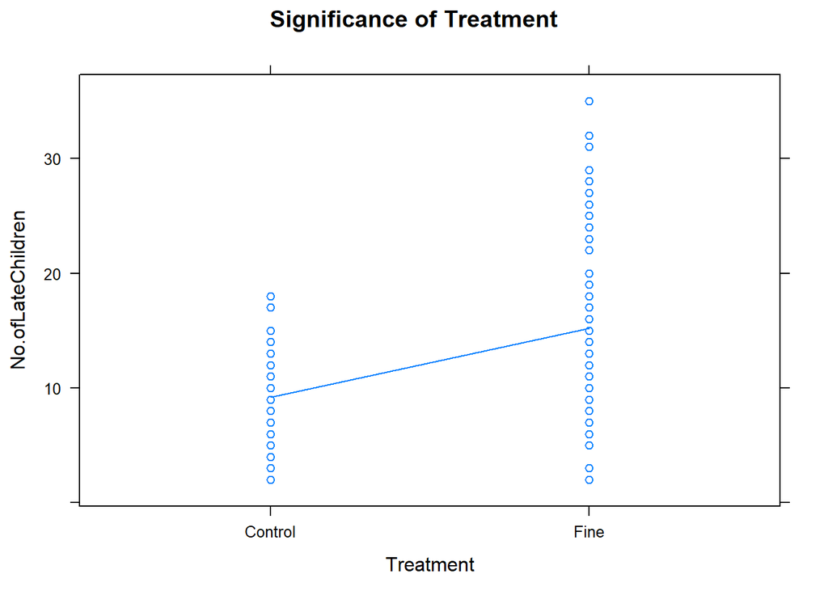

```r
xyplot(No.ofLateChildren ~ Treatment, data=Late, type=c("p","a"), main="Significance of Treatment")
```

This graph compares the average of later students for the seperate treamtens, no fine (control) and the group which was fined. We can see through the graph that the average of late parents is bigger for the fine group.

**Figure 4**

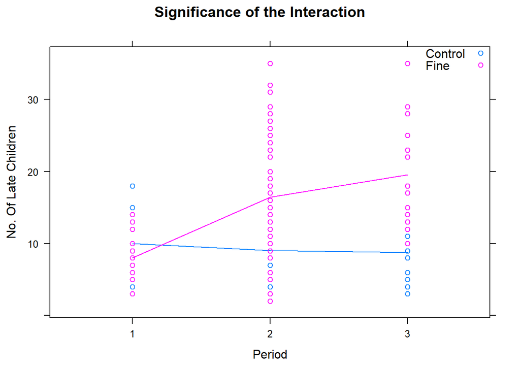

```r
xyplot(No.ofLateChildren ~ Period, data=Late,groups=Treatment, type=c("p","a"), main="Significance of the Interaction", auto.key=list(corner=c(1,1)), ylab = "No. Of Late Children")
```

This graph shows us how many parents were late picking up their children for each treatment group and in each period. This shows us that for the conrtrol group as the number of paretns late decreses over the 3 periods, where as the amount of late parents increases over the 3 periods.

## Interpretation

After reviewing the data there is sufficiant evidence to reject the null hypothesis for each of the three hypotheses presented.

The results of this study lead us to the conclusion that adding the fine had a negative effect on the amount of late parents, leading to an increase of parents who were late picking up their students. They would be better off without a fine. However this does lead us to further question, if the fine was increase each time a parent was late would this then result in less paretents showing up late?